# Data analysis exercise (Exercise 2.2)

Oscar Brück

02.02.2017

# Exercise 2 Data analysis

## Read the dataset from the local folder and analyze the structure of the dataset

```r
setwd("/Users/obruck/Desktop/Open data course/IODS-project/data/")
learning2014 <- read.csv("learning2014.csv", header=TRUE)
str(learning2014)
```

```
## 'data.frame':    166 obs. of  8 variables:
##  $ X       : int  1 2 3 4 5 6 7 8 9 10 ...
##  $ gender  : Factor w/ 2 levels "F","M": 1 2 1 2 2 1 2 1 2 1 ...
##  $ Age     : int  53 55 49 53 49 38 50 37 37 42 ...
##  $ Attitude: int  37 31 25 35 37 38 35 29 38 21 ...
##  $ Deep    : int  43 35 42 42 44 57 46 39 52 48 ...
##  $ Stra    : int  27 22 29 25 29 29 18 32 34 28 ...
##  $ Surf    : int  31 38 27 27 34 29 23 34 26 36 ...
##  $ Points  : int  25 12 24 10 22 21 21 31 24 26 ...
```

```r
dim(learning2014)
```

```
## [1] 166   8
```

The “learning2014” dataset constitutes of 166 observations and 8 variables. The variables (gender, Age, Attitude, Deep, Stra, Surf and Points) describe the results of a query study made as a collaboration international project with teachers.

## Show a graphical overview of the data and show summaries of the variables in the data

```r
summary(learning2014)
```

```
##        X          gender       Age           Attitude          Deep
##  Min.   :  1.00   F:110   Min.   :17.00   Min.   :14.00   Min.   :19.00
##  1st Qu.: 42.25   M: 56   1st Qu.:21.00   1st Qu.:26.00   1st Qu.:40.00
##  Median : 83.50           Median :22.00   Median :32.00   Median :44.00
##  Mean   : 83.50           Mean   :25.51   Mean   :31.43   Mean   :44.16
##  3rd Qu.:124.75           3rd Qu.:27.00   3rd Qu.:37.00   3rd Qu.:49.00
##  Max.   :166.00           Max.   :55.00   Max.   :50.00   Max.   :59.00
##       Stra            Surf           Points
##  Min.   :10.00   Min.   :19.00   Min.   : 7.00
##  1st Qu.:21.00   1st Qu.:29.00   1st Qu.:19.00
##  Median :25.50   Median :34.00   Median :23.00
##  Mean   :24.97   Mean   :33.45   Mean   :22.72
##  3rd Qu.:29.00   3rd Qu.:38.00   3rd Qu.:27.75
##  Max.   :40.00   Max.   :52.00   Max.   :33.00
```

There are 110 female and 56 male students. The median age is 22 years and range [17-55]. Students got a median of 44 points [19-59] in the deep approach (Deep), 25.50 [10-40] in the strategic approach (Stra), 34 points [19-52] in the surface approach (Surf). Their max points were 23 [7-33] as a median (Points).

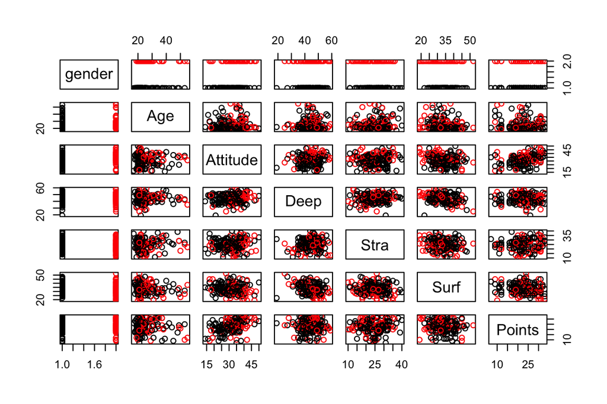

```r
pairs(learning2014[-1], col=learning2014$gender)
```

The data can also be visualised using the “GGally” and “ggplot2” packages

```r
library("GGally")
```

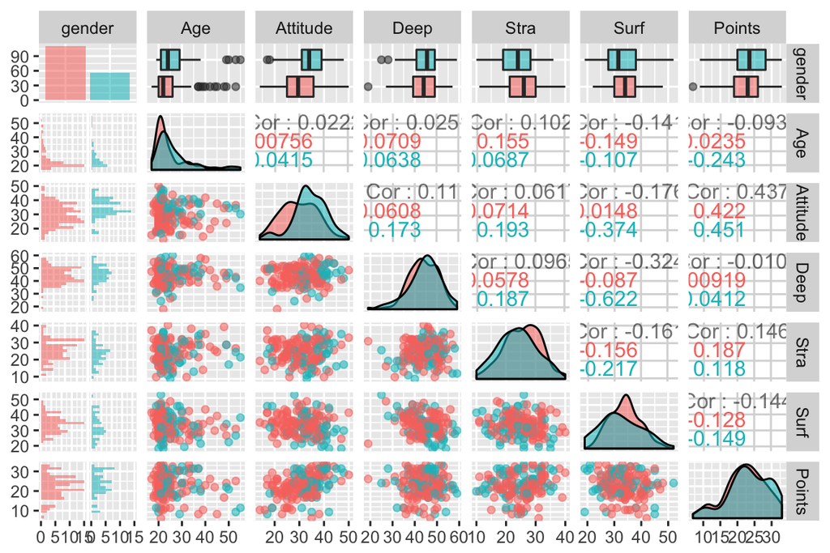

```r
library("ggplot2")
p <- ggpairs(learning2014[-1], mapping = aes(col = gender, alpha = 0.3), lower = list(combo = wrap("facethist", bins = 20)))
p
```

Now we can see that male students have a higher score in attitude questions and female students in strategic questions. We can also see that Variables Points and Attitude have the highest (cor: 0.43) and Surf and Deep second highest correlation factor (cor: 0.32).

## Regression model

The “Points” student achieve is tested with a multivariate linear regression model using Attitude, Stra and Surf as independent variables. The model tries to describe any linear correlation between the independent and dependent variables.

```r
points_regression <- lm(Points ~ Attitude + Stra + Surf, data = learning2014)
summary(points_regression)
```

```
##
## Call:
## lm(formula = Points ~ Attitude + Stra + Surf, data = learning2014)
##
## Residuals:
##      Min       1Q   Median       3Q      Max
## -17.1550  -3.4346   0.5156   3.6401  10.8952
##
## Coefficients:
##             Estimate Std. Error t value Pr(>|t|)
## (Intercept) 11.01711    3.68375   2.991  0.00322 **
## Attitude     0.33952    0.05741   5.913 1.93e-08 ***
## Stra         0.10664    0.06770   1.575  0.11716
## Surf        -0.04884    0.06678  -0.731  0.46563
## ---
## Signif. codes:  0 '***' 0.001 '**' 0.01 '*' 0.05 '.' 0.1 ' ' 1
##
## Residual standard error: 5.296 on 162 degrees of freedom
## Multiple R-squared:  0.2074, Adjusted R-squared:  0.1927
## F-statistic: 14.13 on 3 and 162 DF,  p-value: 3.156e-08
```

In the first model with all three variables, Attitude explains the Points with a coefficient estimate of 0.34 (p<0.0001). Other variables Stra and Surf do not explain Points with a statistical significance. Thus, first Surf is removed and the model is tested again.

```r
points_regression <- lm(Points ~ Attitude + Stra, data = learning2014)
summary(points_regression)
```

```
##
## Call:
## lm(formula = Points ~ Attitude + Stra, data = learning2014)
##
## Residuals:
##      Min       1Q   Median       3Q      Max
## -17.6436  -3.3113   0.5575   3.7928  10.9295
##
## Coefficients:
##             Estimate Std. Error t value Pr(>|t|)
## (Intercept)  8.97290    2.39591   3.745  0.00025 ***
## Attitude     0.34658    0.05652   6.132 6.31e-09 ***
## Stra         0.11421    0.06681   1.709  0.08927 .
## ---
## Signif. codes:  0 '***' 0.001 '**' 0.01 '*' 0.05 '.' 0.1 ' ' 1
##
## Residual standard error: 5.289 on 163 degrees of freedom
## Multiple R-squared:  0.2048, Adjusted R-squared:  0.1951
## F-statistic: 20.99 on 2 and 163 DF,  p-value: 7.734e-09
```

Attitude is still the only relevant variable and, thus, Stra is removed and the model is run with Attitude alone (coefficient 0.35, p<0.0001).

```r
points_regression <- lm(Points ~ Attitude, data = learning2014)
summary(points_regression)
```

```
##
## Call:
## lm(formula = Points ~ Attitude, data = learning2014)
##
## Residuals:
##      Min       1Q   Median       3Q      Max
## -16.9763  -3.2119   0.4339   4.1534  10.6645
##
## Coefficients:
##             Estimate Std. Error t value Pr(>|t|)
## (Intercept) 11.63715    1.83035   6.358 1.95e-09 ***
## Attitude     0.35255    0.05674   6.214 4.12e-09 ***
## ---
## Signif. codes:  0 '***' 0.001 '**' 0.01 '*' 0.05 '.' 0.1 ' ' 1
##
## Residual standard error: 5.32 on 164 degrees of freedom
## Multiple R-squared:  0.1906, Adjusted R-squared:  0.1856
## F-statistic: 38.61 on 1 and 164 DF,  p-value: 4.119e-09
```

The adjusted R-squared score is 0.19 meaning that using this model, Attitude explains 19% of the total variance of the dependent variable Points.

## Residuals vs Fitted values, Normal QQ-plot and Residuals vs Leverage

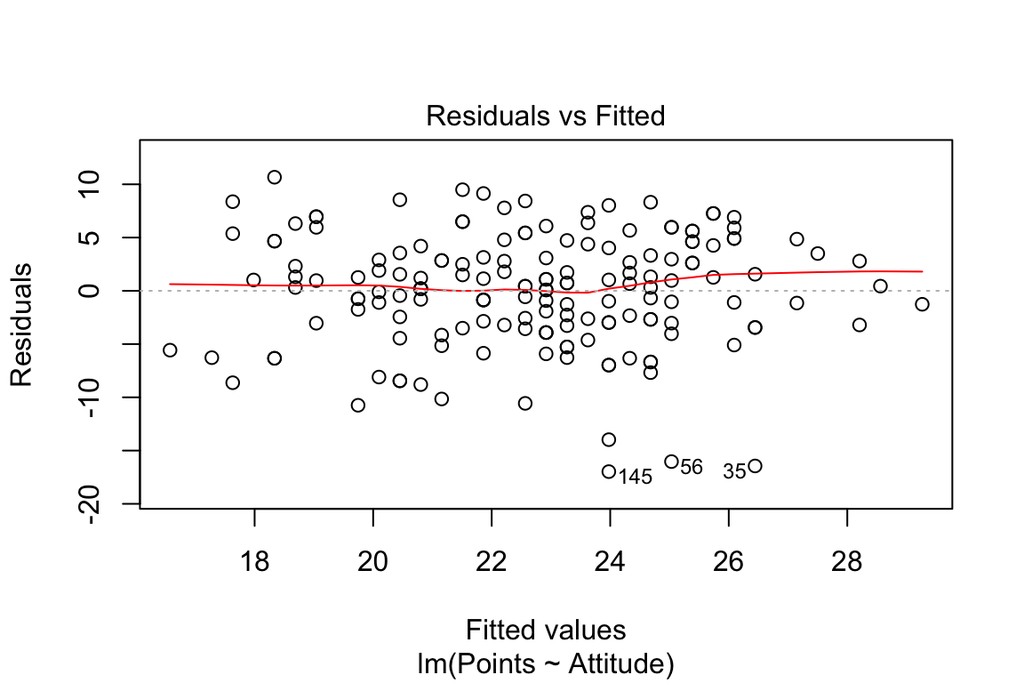

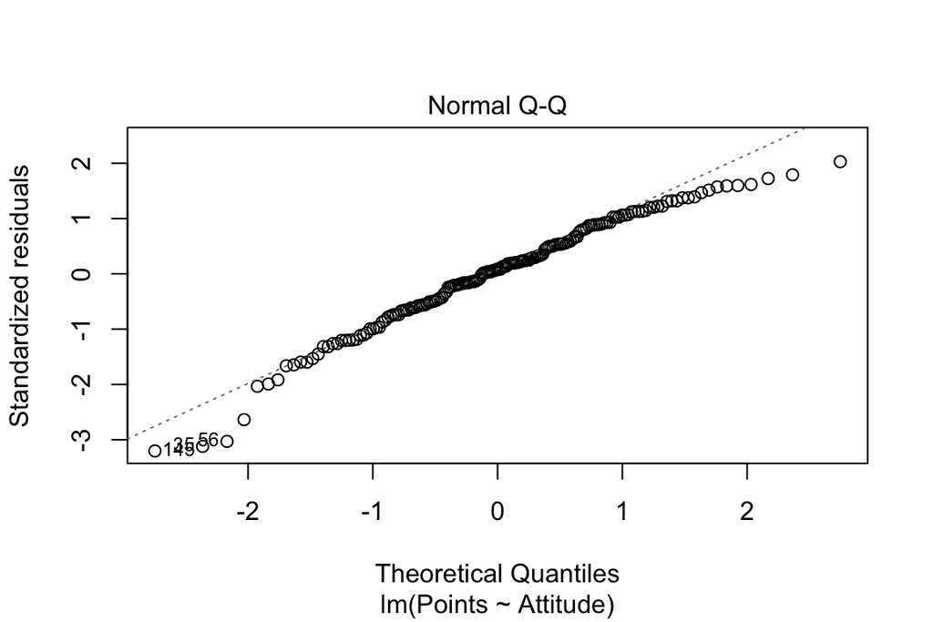

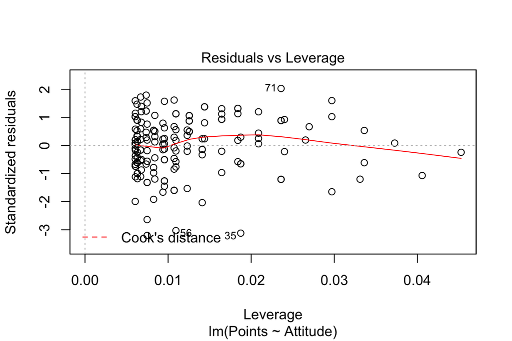

```r
plot(points_regression, which = c(1,2,5))
```

Residuals of the linear regression model describe the validity of the model. Residuals should be normally distributed, they should not correlate with each others, have a constant varaiance and their size should not depend on the size of the independent variable.  
The QQ-plot describes the distribution of the residuals. Our model is normally divided as the measurements are set on straight increasing line.  
The Residuals vs Fitted plot describes how the residuals depend on the explanatory variable. According to the plot, the resudials are resonably evenly distributed on both sides of the residual level = 0 line and, thus, do not depend on the size of the explanatory variable.  
The Residuals vs Leverage plot can help identify, which observations have an unusually high impact on the model. According to the plot, all measurements are divided between [0,0.05] and thus none have an unusual impact on the model.